# ST661: Group8

Chunmei Luo, Shefali Shashidhar Bhandary, Christos Souliotis and Samanyu Sen

2022-12-11

## PISA Data Analysis

### Part 1: Introduction

PISA is an international student assessment measuring education and school systems through different countries. It is well known that education is important to both individuals and countries, which is why more and more countries are investing the educational level and joining PISA. It’s also the dataset we use in this report. The main objective of this report is to research the potential factors contributing the student’s total performance in in Math, Science, and Reading. The main factors we are going to analysis in this report concludes parent’s education level, home possession and school type. We have taken into consideration mainly the data from the PISA2018 because it is the most recent data, and it will give us the most up to date results.

This report and graphical tools are all developed using R. Here we are manipulating and visualizing the data to get information on the effect of the data. The data was available in the CRAN package - ‘learningtower’ and more information about the research was found on the website www.oecd.org/PISA .The data was collected by multiple Questionnaires like questionnaires administered to students about their well-being, educational career, financial literacy and ICT familiarity, to school principals, teachers and their parents. As a result, the dataset gathered a plethora of information about the educational performance and environment they grow up.

### Part 2: Data Wrangling and Cleaning

To produce the required results we have joined the student_subset_2018 dataset with countrycode dataset and school dataset available in the learningtower library. We have used the dplyr and ggplot libraries in R for our data manipulation and visualization.

To make the code more efficient, we have deleted the rows which contained null and missing values and columns which would not impact our results. In addition to that we changed the type of some variables, where appropriate, to be able to create our graphs.

In our research we explored the effect that gender, parent’s education level, family’s possessions and school type have on the student’s scores. We added two new columns: total score and average score, to check the correlation.

### Part 3: Data Analysis

**3.1 Gender difference on scores?**

In this part of analysis, we compared scores by gender from PISA2018 which you can see from the first graph (Fig 3.1) that females have better read scores, while males do better at math, and have similar scores for science. We don’t see obvious difference among three subject. From the second graph (Fig 3.2) involving time series, it’s clear that females have a higher overall score than males through all years 2000-2018, but when you look at the numbers, score difference is within 10 points.

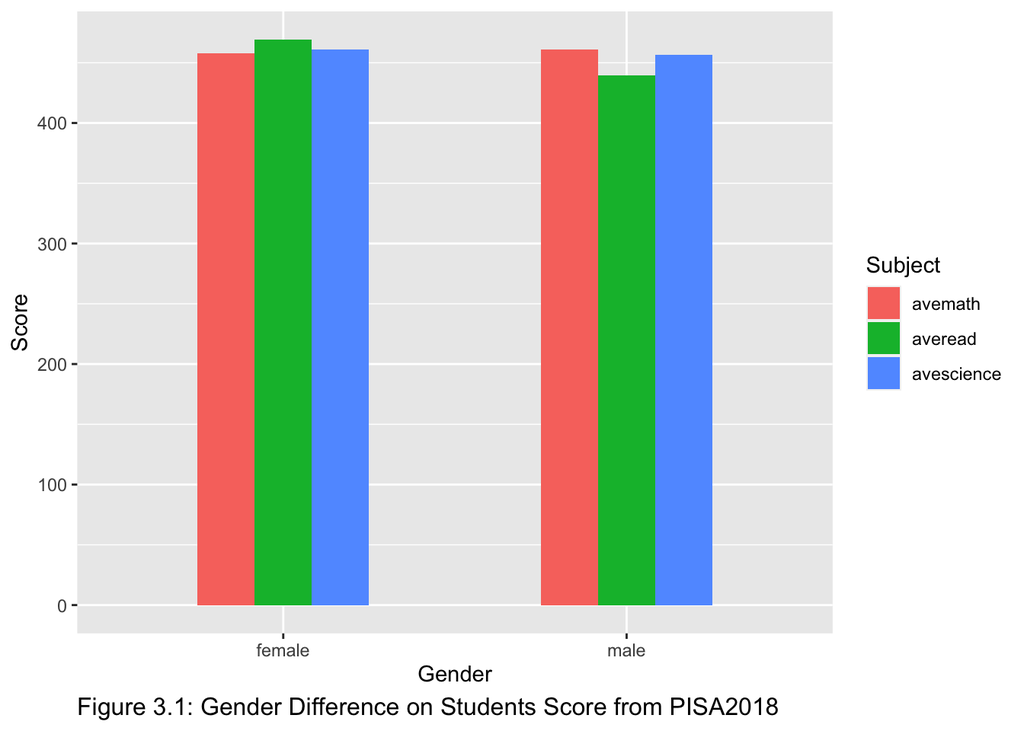

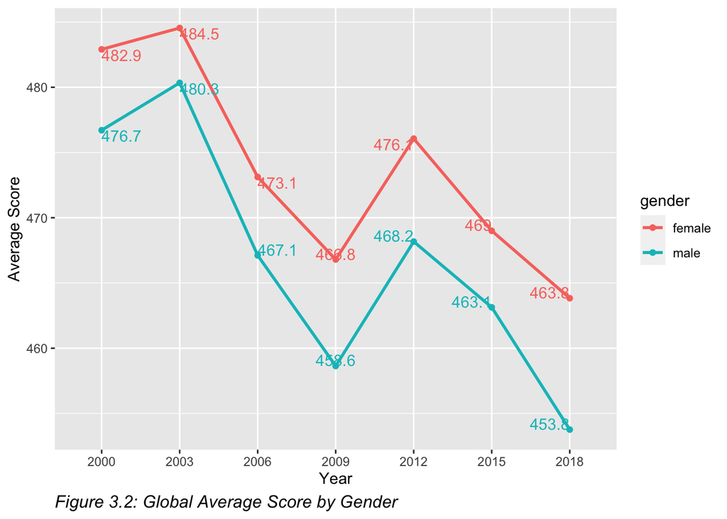

**3.2 Impact of Parents on Student Scores**

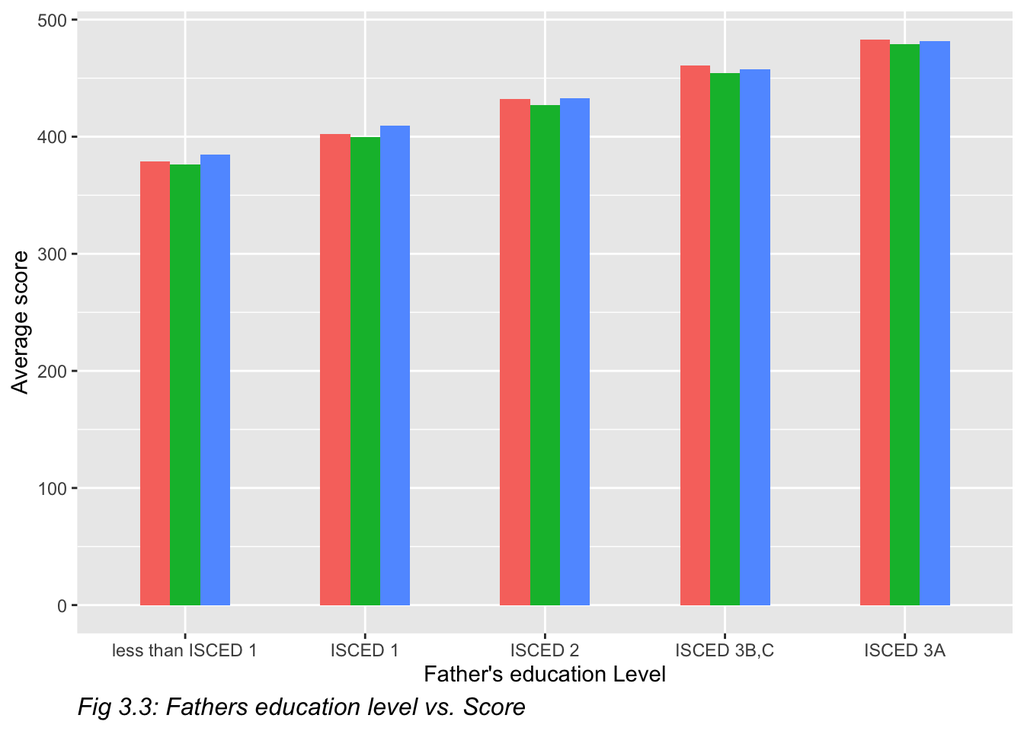

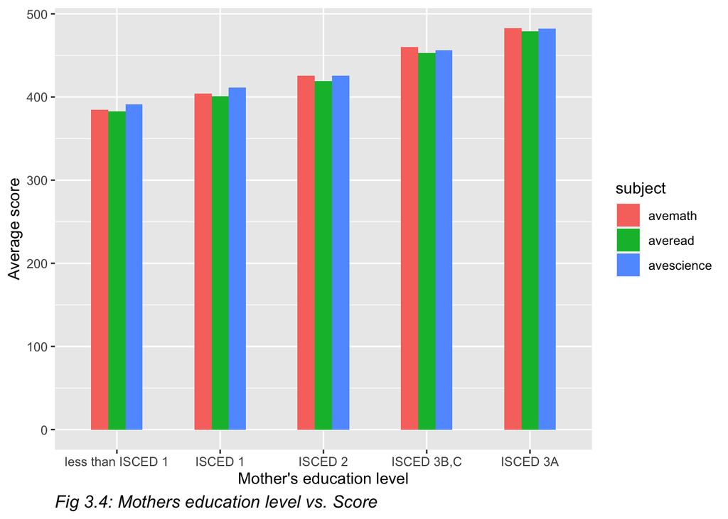

According to the graphs above, we can see a similarity in the trends of all subjects. We compare the correlations among the three subjects of Math, Reading and Science (Fig 3.5). We can conclude that all three subjects are highly correlated, so with this strong relationship, we are going to use the average score of Math, Science and Read as Average Score to measure the student’s performance for the following graphs in our report.

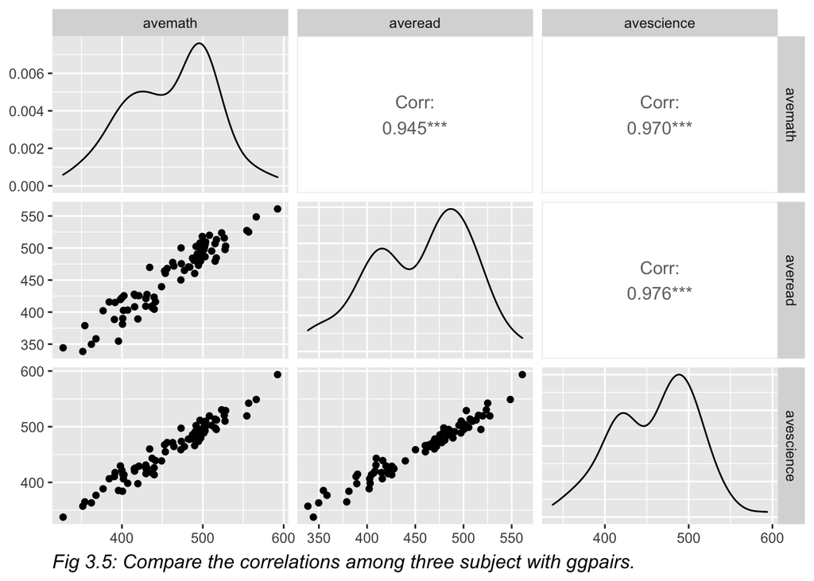

**3.3 Impact of Family Possession**

The first graph (Fig 3.6.1) below shows what percentage of students have internet, computer, desk and their own room at their home. Most of the students have these resources but in varying percentages. The second graph (Fig 3.6.1) further looks at how these resources are going to impact the student scores. We can conclude that the students who have access to internet, computer, desk and have their own room tend to have a better performance on scores

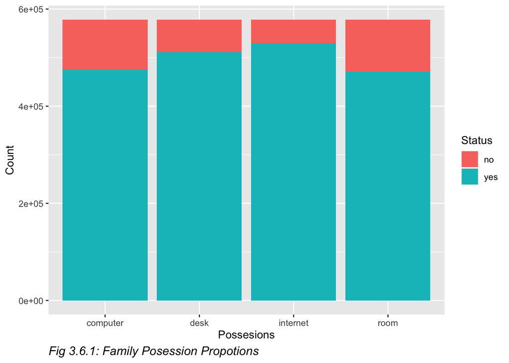

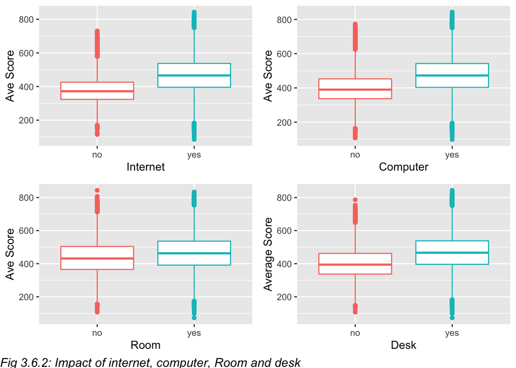

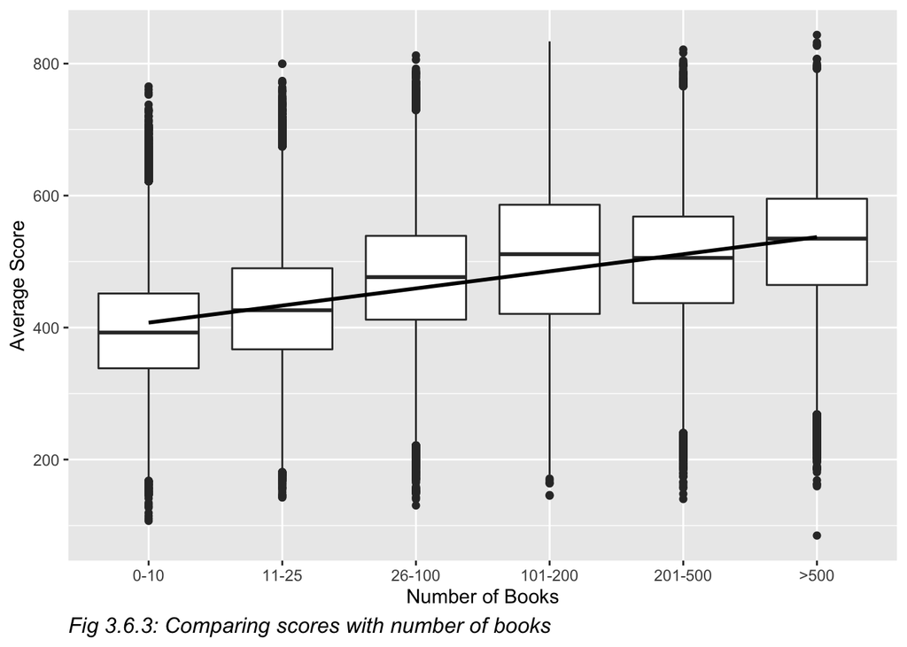

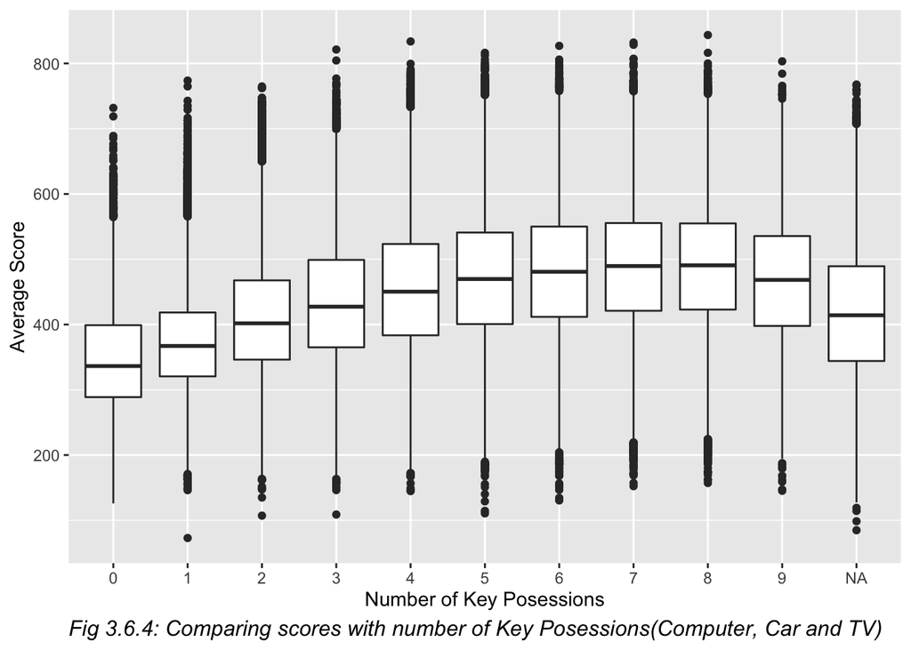

**3.4 Impact of School Type on Students Score**

Using the data from school and student data set for the 2018 data, we can check whether the following parameters have any impact on the scores of the students. As expected, private school students do better than public school students (Fig 3.7).

Comparing scores between public and private schools depending on staff shortage. We can see no correlation between staff shortage and scores. There appears to be a positive effect on scores for schools that are bigger. We can say that students who study at bigger schools would get better scores regardless of how short staffed the school is. (Fig 3.8)

Comparing scores between public and private schools depending on source of funding. We can see no correlation between source of funding and scores for government funding, but we can see a negative effect on scores when most of the funding comes from donations. It can be said that schools that are funded mostly through donations tend to have lower scores when compared to other schools. (Fig 3.9)

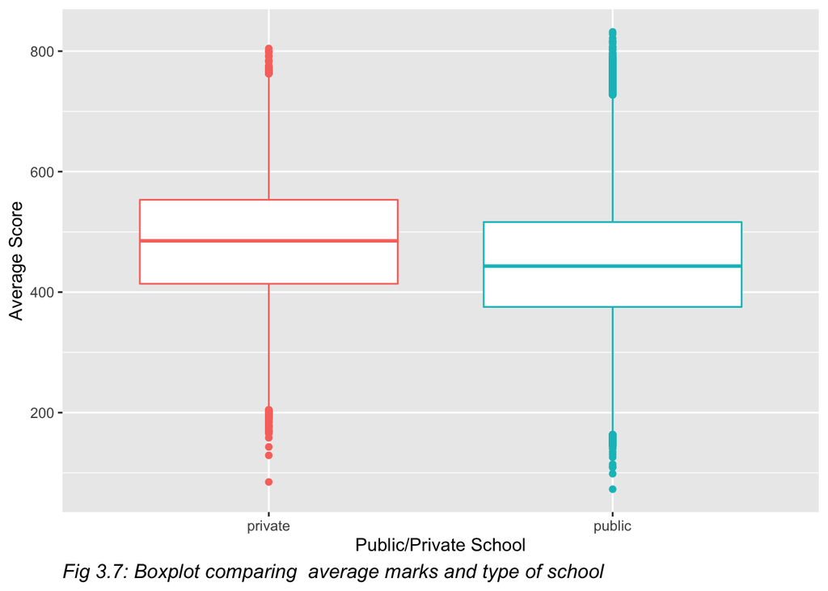

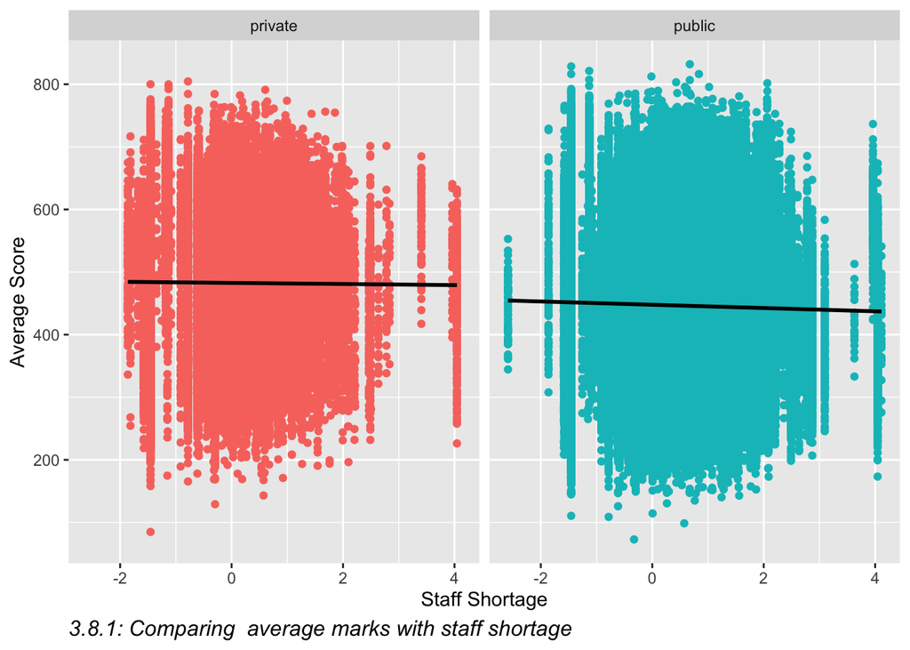

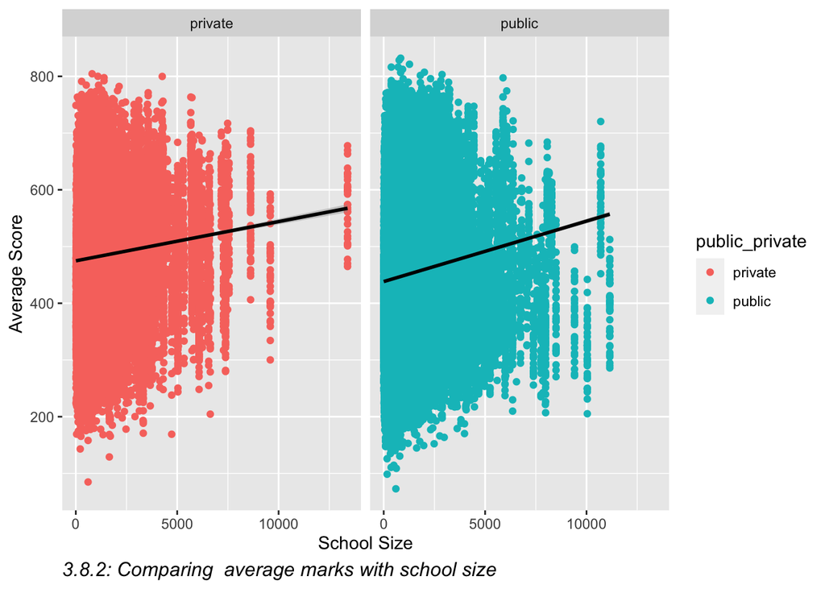

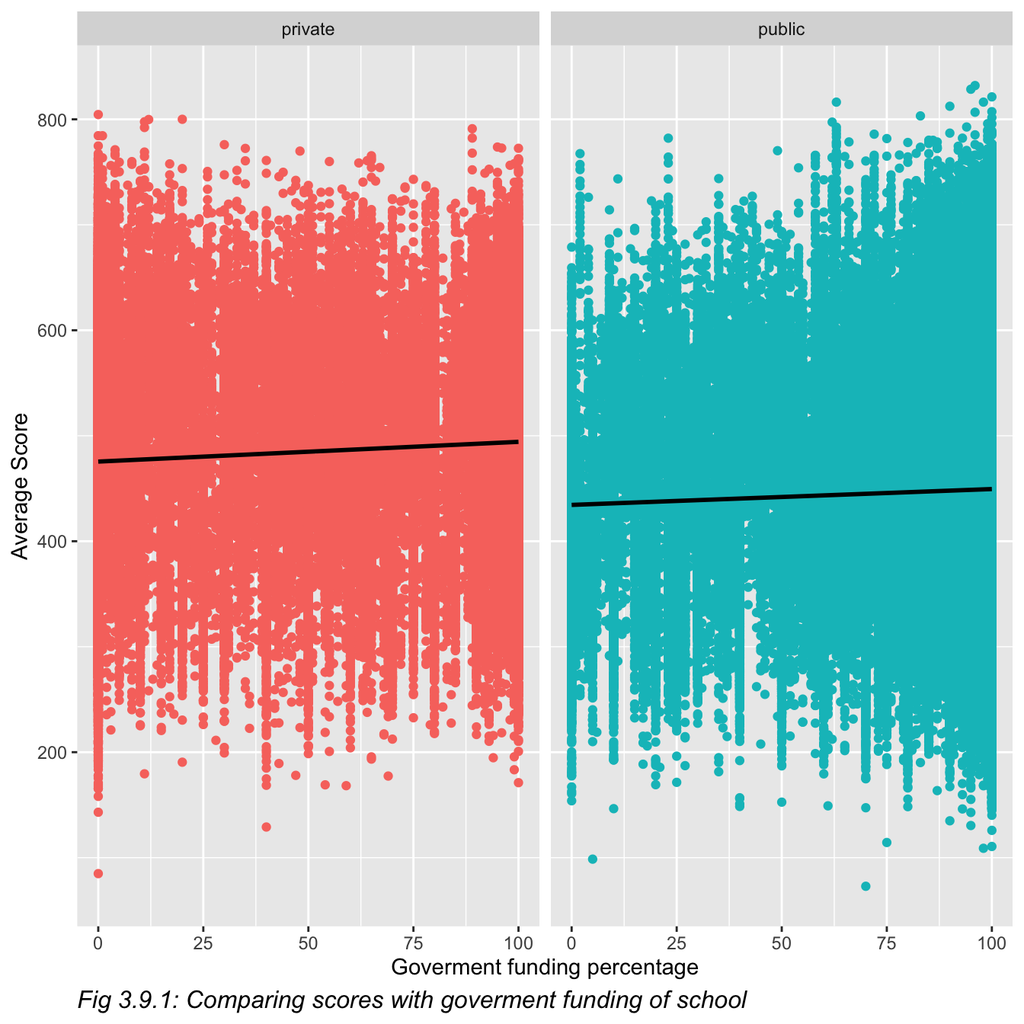

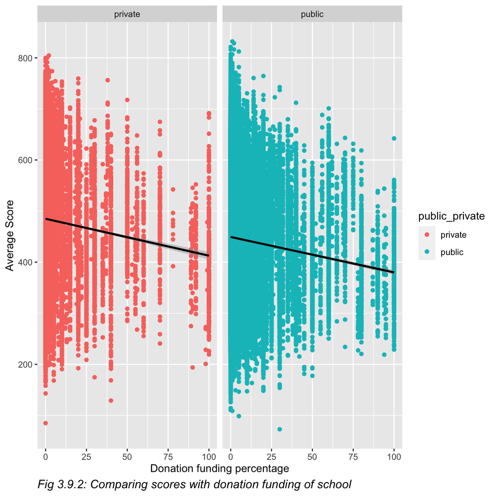

### Part 4: Conclusion

By performing the general analysis of gender differences on students’ scores we recognize females perform better than males through all those years even though there is a similar trend among both genders from the year 2000 to 2018. By looking into correlation between global average score and individual scores we can positively use averages for our deductions.

Through our further analysis, we can see how different factors like parent’s education, financial status of the family, the type of school a student goes to, and availability of other resources can play a role in influencing the scores of the student. In conclusion, we can see parent’s education, home possessions, type of school can have a positive effect on the scores.

**Appendices**

I, Chunmei (21250819), had primary responsibility of compiling and formatting report, and analysis on parents education, home possession and gender and guide through the project.

I, Shefali (22250136), had primary responsibility of initial analysis of the data and for the write up of Introduction, Data Wrangling and Conclusion in the report and help with gender analysis.

I, Chris (22252598), had primary responsibility for writing up the report(part1, 2, 4), presentation and help with home possession analysis.

I, Samanyu (22250548), had primary responsibility for school analysis and the editing of the report, and helped in the writing and formatting of the report.